# problem set #4, 602

Jaclynn Martinez

2026-11-26

```r
df<- read.csv("thermometers_hw04.csv")
df <- df %>%
  filter(!is.na(ft_immig) & ft_immig != "") %>%
  filter(!is.na(ft_dem) & ft_dem != "")
```

# 1.a

```r
#recoding ft_immig column --> *do not change into factor! then you can't run the regression
df$ft_immig[df$ft_immig%in% 0:19]<-1
df$ft_immig[df$ft_immig%in% 20:39]<-2
df$ft_immig[df$ft_immig%in%40:59]<-3
df$ft_immig[df$ft_immig%in% 60:79]<-4
df$ft_immig[df$ft_immig%in%80:100]<-5

#checking new values
table(df$ft_immig)
```

```
##
##    1    2    3    4    5
##  437  365 1232 1128 1462
```

```r
im_dem_model<- lm(ft_immig~ft_dem, data=df)
summary(im_dem_model)
```

```
##
## Call:
## lm(formula = ft_immig ~ ft_dem, data = df)
##
## Residuals:
##     Min      1Q  Median      3Q     Max
## -3.4184 -0.7499  0.1100  0.8057  2.1828
##
## Coefficients:
##              Estimate Std. Error t value Pr(>|t|)
## (Intercept) 2.8171825  0.0290324   97.04   <2e-16 ***
## ft_dem      0.0160125  0.0004809   33.30   <2e-16 ***
## ---
## Signif. codes:  0 '***' 0.001 '**' 0.01 '*' 0.05 '.' 0.1 ' ' 1
##
## Residual standard error: 1.135 on 4622 degrees of freedom
## Multiple R-squared:  0.1935, Adjusted R-squared:  0.1933
## F-statistic:  1109 on 1 and 4622 DF,  p-value: < 2.2e-16
```

A one unit increase on the feeling thermometer for democrats is associated with a 0.016 unit higher expected value of the warmth feeling thermometer for immigrants.

# 1.b

```r
df<-df %>%
  mutate(two=ifelse(ft_immig>=2 ,1,0))%>%
  mutate(three= ifelse(ft_immig>=3,1,0))%>%
  mutate(four=ifelse(ft_immig>=4,1,0))%>%
  mutate(five=ifelse( ft_immig>= 5,1,0))

b_model_two<-lm(two~ft_dem,data=df)
b_model_three<-lm(three~ft_dem,data=df)
b_model_four<-lm(four~ft_dem,data=df)
b_model_five<-lm(five~ft_dem,data=df)

summary(b_model_two)
```

```
##
## Call:
## lm(formula = two ~ ft_dem, data = df)
##
## Residuals:
##      Min       1Q   Median       3Q      Max
## -1.01167  0.00932  0.06598  0.14993  0.19820
##
## Coefficients:
##              Estimate Std. Error t value Pr(>|t|)
## (Intercept) 0.8017981  0.0072512  110.58   <2e-16 ***
## ft_dem      0.0020987  0.0001201   17.48   <2e-16 ***
## ---
## Signif. codes:  0 '***' 0.001 '**' 0.01 '*' 0.05 '.' 0.1 ' ' 1
##
## Residual standard error: 0.2834 on 4622 degrees of freedom
## Multiple R-squared:  0.06197,    Adjusted R-squared:  0.06177
## F-statistic: 305.4 on 1 and 4622 DF,  p-value: < 2.2e-16
```

```r
summary(b_model_three)
```

```
##
## Call:
## lm(formula = three ~ ft_dem, data = df)
##
## Residuals:
##      Min       1Q   Median       3Q      Max
## -0.99830  0.00849  0.09336  0.23933  0.34118
##
## Coefficients:
##              Estimate Std. Error t value Pr(>|t|)
## (Intercept) 0.6588218  0.0092095   71.54   <2e-16 ***
## ft_dem      0.0033948  0.0001525   22.26   <2e-16 ***
## ---
## Signif. codes:  0 '***' 0.001 '**' 0.01 '*' 0.05 '.' 0.1 ' ' 1
##
## Residual standard error: 0.3599 on 4622 degrees of freedom
## Multiple R-squared:  0.0968, Adjusted R-squared:  0.0966
## F-statistic: 495.3 on 1 and 4622 DF,  p-value: < 2.2e-16
```

```r
summary(b_model_four)
```

```
##
## Call:
## lm(formula = four ~ ft_dem, data = df)
##
## Residuals:
##     Min      1Q  Median      3Q     Max
## -0.8500 -0.3687  0.1557  0.3391  0.7230
##
## Coefficients:
##              Estimate Std. Error t value Pr(>|t|)
## (Intercept) 0.2770185  0.0116402   23.80   <2e-16 ***
## ft_dem      0.0057298  0.0001928   29.72   <2e-16 ***
## ---
## Signif. codes:  0 '***' 0.001 '**' 0.01 '*' 0.05 '.' 0.1 ' ' 1
##
## Residual standard error: 0.4549 on 4622 degrees of freedom
## Multiple R-squared:  0.1604, Adjusted R-squared:  0.1603
## F-statistic: 883.3 on 1 and 4622 DF,  p-value: < 2.2e-16
```

```r
summary(b_model_five)
```

```
##
## Call:
## lm(formula = five ~ ft_dem, data = df)
##
## Residuals:
##     Min      1Q  Median      3Q     Max
## -0.5585 -0.3298 -0.1274  0.4607  0.9205
##
## Coefficients:
##              Estimate Std. Error t value Pr(>|t|)
## (Intercept) 0.0795440  0.0111145   7.157 9.56e-13 ***
## ft_dem      0.0047892  0.0001841  26.016  < 2e-16 ***
## ---
## Signif. codes:  0 '***' 0.001 '**' 0.01 '*' 0.05 '.' 0.1 ' ' 1
##
## Residual standard error: 0.4344 on 4622 degrees of freedom
## Multiple R-squared:  0.1277, Adjusted R-squared:  0.1275
## F-statistic: 676.9 on 1 and 4622 DF,  p-value: < 2.2e-16
```

```r
#adding together all slopes to ensure they are the same as the lm model run in part (a)
0.0047892+0.0057298+0.0033948+0.0020987
```

```
## [1] 0.0160125
```

Slope when variable is 2: 0.002  
Slope when variable is 3: 0.003  
Slope when variable is 4: 0.006 (0.0057)  
Slope when variable is 5: 0.005 (0.0047)  
Each of the slopes are different.  
The greatest probability of moving up a category is when the variable is 4 or greater but when the variable is 5 or greater the slope decreases slightly.  
Adding up all the slopes:  
0.0047892+0.0057298+0.0033948+0.0020987 = 0.0160125  
When added all together, the four slopes equal the slope found in part (a), which included all categorical variables 1-5.

# 1.c

```r
im_dem_model
```

```
##
## Call:
## lm(formula = ft_immig ~ ft_dem, data = df)
##
## Coefficients:
## (Intercept)       ft_dem
##     2.81718      0.01601
```

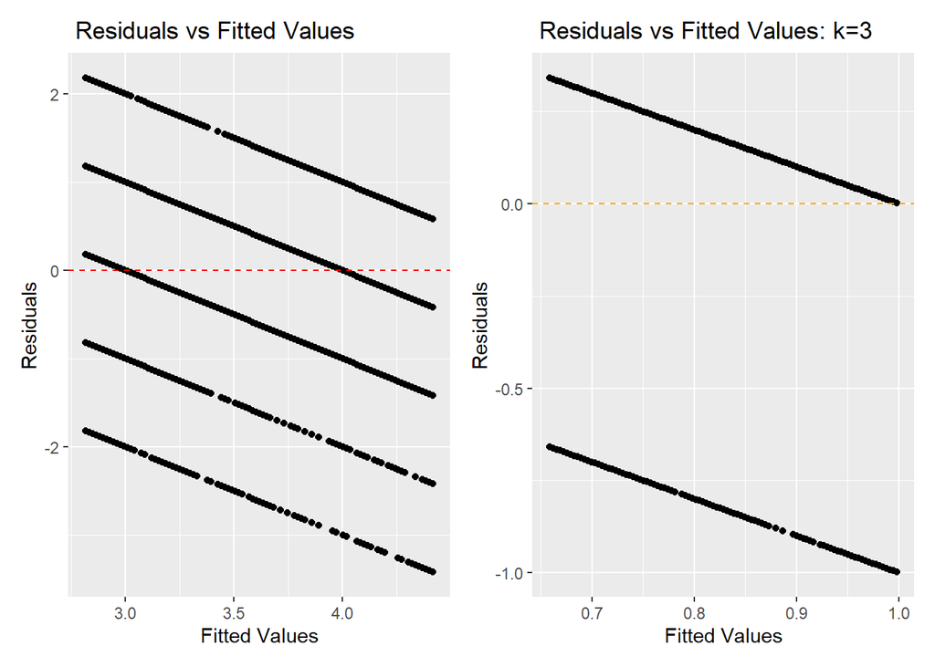

```r
residuals<-resid(im_dem_model)
fitted<-fitted(im_dem_model)

a<- ggplot(df,aes(x=fitted, y= residuals))+
  geom_point()+
  geom_hline(yintercept=0, linetype="dashed", color="red")+
  labs(x= "Fitted Values", y= "Residuals",
       title= " Residuals vs Fitted Values")

# residual vs fitted plot for k=3
residuals.b<-resid(b_model_three)
fitted.b<-fitted(b_model_three)
b<-ggplot(df,aes(x=fitted.b, y= residuals.b))+
  geom_point()+
  geom_hline(yintercept=0, linetype="dashed", color="orange")+
  labs(x= "Fitted Values", y= "Residuals",
       title= " Residuals vs Fitted Values: k=3")

a+b
```

The errors are not constant. They create lines in the graph; which represent each categorical variable. For the plot representing k=3, the variable used in the lm model only has two outcomes: 1 or 0. Thus, there are only two bands represented in the plot.

# 1.d

```r
#resetting the ft_immig numbers back to thermometer.

df<- read.csv("thermometers_hw04.csv")
df <- df %>%
  filter(!is.na(ft_immig) & ft_immig != "") %>%
  filter(!is.na(ft_dem) & ft_dem != "")


k<- c(3,5,10,50,100) #creating k
results<- data.frame(k= integer(), slopecat_converted=numeric(), r2of.cat= numeric(),slope_t=numeric(), r2.t=numeric()) #empty vector to store loop results.


for(k in k){
  ft.immig_cat<-cut(df$ft_immig,
         breaks=seq(min(df$ft_immig),max(df$ft_immig),length.out= k+1),labels= FALSE, include.lowest = TRUE) #creating cutoff points k

  model.ftimmig.cat<- lm (ft.immig_cat~ ft_dem, data=df) #creating a lm model using the categorical version of ft_immig

  slopeof.cat<- coef(model.ftimmig.cat)["ft_dem"] # slope of categorical ft_immig
  r2of.cat<- summary(model.ftimmig.cat)$r.squared

  slopecat_converted<- (slopeof.cat*100)/k #converting slope from categorical back to thermom. scale.

  #original thermometer regression to compare k slope values against
model.t<-lm(ft_immig~ft_dem, data=df)
slope_t<- coef(model.t)["ft_dem"]
r2.t<- summary(model.t)$r.squared

results<- rbind(results, data.frame(k=k,
                                    slopecat_converted=slopecat_converted,
                                    r2of.cat=r2of.cat,
                                    slope_t=slope_t,
                                    r2.t=r2.t))


}

print(results)
```

```
##           k slopecat_converted  r2of.cat   slope_t      r2.t
## ft_dem    3          0.2999943 0.1795679 0.3540636 0.2046354
## ft_dem1   5          0.3186773 0.1943966 0.3540636 0.2046354
## ft_dem2  10          0.3423534 0.2014061 0.3540636 0.2046354
## ft_dem3  50          0.3529558 0.2043330 0.3540636 0.2046354
## ft_dem4 100          0.3536631 0.2045871 0.3540636 0.2046354
```

As K increases the categorical slope and r2 (slopecat_converted & r2.cat) grows similar to the original thermometer slope and r2 score (slope_t & r2.t).  
Thus, the more categories you have the more accurate your regression coefficients will be.